# Homework 1, Biostatistics

# Q1

```r
binom.test(12,85,p=0.5,alt='two.sided',conf.level = 0.95)
```

```
##
##  Exact binomial test
##
## data:  12 and 85
## number of successes = 12, number of trials = 85, p-value = 8.091e-12
## alternative hypothesis: true probability of success is not equal to 0.5
## 95 percent confidence interval:
##  0.07513135 0.23362462
## sample estimates:
## probability of success
##              0.1411765
```

```r
binom.test(12,85,p=0.8,alt='two.sided',conf.level = 0.95)
```

```
##
##  Exact binomial test
##
## data:  12 and 85
## number of successes = 12, number of trials = 85, p-value < 2.2e-16
## alternative hypothesis: true probability of success is not equal to 0.8
## 95 percent confidence interval:
##  0.07513135 0.23362462
## sample estimates:
## probability of success
##              0.1411765
```

```r
binom.test(12,85,p=0.5,alt='two.sided',conf.level = 0.99)
```

```
##
##  Exact binomial test
##
## data:  12 and 85
## number of successes = 12, number of trials = 85, p-value = 8.091e-12
## alternative hypothesis: true probability of success is not equal to 0.5
## 99 percent confidence interval:
##  0.06036021 0.26403358
## sample estimates:
## probability of success
##              0.1411765
```

```r
prop.test(12,85,alt='two.side',correct = F)
```

```
##
##  1-sample proportions test without continuity correction
##
## data:  12 out of 85, null probability 0.5
## X-squared = 43.776, df = 1, p-value = 3.681e-11
## alternative hypothesis: true p is not equal to 0.5
## 95 percent confidence interval:
##  0.08264233 0.23074130
## sample estimates:
##         p
## 0.1411765
```

# ——————————————————————————–

# Q2

## (a)

we can create a table

table0

|  | dead | survival | Total |
| --- | --- | --- | --- |
| control | 4 | 15 | 19 |
| case | 2 | 13 | 15 |
| Total | 6 | 28 | 34 |

# if $H_{0}: p1 = p2$ vs $H_{1}: p1 > p2$

table1

|  | dead | survival | Total |
| --- | --- | --- | --- |
| control | 5 | 14 | 19 |
| case | 1 | 14 | 15 |
| Total | 6 | 28 | 34 |

table2

|  | dead | survival | Total |
| --- | --- | --- | --- |
| control | 6 | 13 | 19 |
| case | 0 | 15 | 15 |
| Total | 6 | 28 | 34 |

p_value = Pr(table1|$H_0$) + Pr(table2|$H_0$) + Pr(table0|$H_0$)

```r
p_value=0
for (i in c(4:6)){
  p_value = p_value + choose(6,i)*choose(28,19-i)/choose(34,19)
}
print(p_value)
```

```
## [1] 0.4524724
```

check

```r
m=matrix(c(4,2,15,13),c(2,2),dimnames = list(c('control','streptokinase'),c('died','survival')))
fisher.test(m,alt='greater')$p.value
```

```
## [1] 0.4524724
```

# if $H_{0}: p1 = p2$ vs $H_{1}: p1 < p2$

table3

|  | dead | survival | Total |
| --- | --- | --- | --- |
| control | 3 | 16 | 19 |
| case | 3 | 12 | 15 |
| Total | 6 | 28 | 34 |

table4

|  | dead | survival | Total |
| --- | --- | --- | --- |
| control | 2 | 17 | 19 |
| case | 4 | 11 | 15 |
| Total | 6 | 28 | 34 |

table5

|  | dead | survival | Total |
| --- | --- | --- | --- |
| control | 1 | 18 | 19 |
| case | 5 | 10 | 15 |
| Total | 6 | 28 | 34 |

table6

|  | dead | survival | Total |
| --- | --- | --- | --- |
| control | 0 | 19 | 19 |
| case | 6 | 9 | 15 |
| Total | 6 | 28 | 34 |

p_value = Pr(table3|$H_0$) + Pr(table4|$H_0$) + Pr(table5|$H_0$) + Pr(table6|$H_0$) + Pr(table0|$H_0$)

```r
p_value=0
for (i in c(4:0)){
  p_value = p_value + choose(6,i)*choose(28,19-i)/choose(34,19)
}
print(p_value)
```

```
## [1] 0.8501365
```

check

```r
m=matrix(c(4,2,15,13),c(2,2),dimnames = list(c('control','streptokinase'),c('died','survival')))
fisher.test(m,alt='less')$p.value
```

```
## [1] 0.8501365
```

# if $H_{0}: p1 = p2$ vs $H_{1}: p1 \neq p2$

p-value = take sum all table when Pr(tablei|$H_0$) < Pr(table0|$H_0$)

```r
p_value=0
for (i in c(0:6)){
  r= choose(6,i)*choose(28,19-i)/choose(34,19)
  if (r<=choose(6,4)*choose(28,19-4)/choose(34,19)){
    p_value = p_value + r
  }
}
print(p_value)
```

```
## [1] 0.6721736
```

check

```r
m=matrix(c(4,2,15,13),c(2,2),dimnames = list(c('control','streptokinase'),c('died','survival')))
fisher.test(m,)$p.value
```

```
## [1] 0.6721736
```

## (b)

```r
m=matrix(c(4,2,15,13),c(2,2),dimnames = list(c('control','streptokinase'),c('died','survival')))
chisq.test(m)
```

```
##
##  Pearson's Chi-squared test with Yates' continuity correction
##
## data:  m
## X-squared = 0.017753, df = 1, p-value = 0.894
```

## Conclusion : whether fisher exact test or chi_square test always do not reject $H_0$ (i.e mortality rate is equal)

## (c)

power = 90% ,P1 = 0.2

$H_0:P2 = 0.2 \ vs\ H_1:P2 \neq 0.2$  
at $\alpha$=0.05  
$\hat{P_1}$ ~ $N(0.2,0.16/n)$  
$\hat{P_2}$ ~ $N(P_2,P_2(1-P_2)/n)$  
$\hat{P_2}-\hat{P_1}$ ~ $N((P_2-0.2),(0.16+P_2(1-P_2))/n)$  
critical region = $\frac{\hat{P_2}-\hat{P_1}}{\sqrt{0.32/n}}$ > $z_{\alpha/2}$  
= $\hat{P_2}-\hat{P_1}$ > $z_{\alpha/2} \times \sqrt{\frac{32}{n}}$

0.45 = Pr(critical region | $H_1$ is true) = Pr($\hat{P_2}-\hat{P_1}$ > $z_{\alpha/2} \times \sqrt{\frac{32}{n}}$|P2)  
0.45 = Pr(Z > $(z_{\alpha/2} \times \sqrt{\frac{32}{n}}-(P_2-0.2))$ / $\sqrt{\frac{0.16+P_2(1-P_2)}{n}}$)

and $z_{0.45} = 0.3264$

$n^{1/2} = (-0.3264 \times \sqrt{0.16 + P_2(1-P_2)} + 1.96\times \sqrt{0.32}) /(P_2-0.2)$

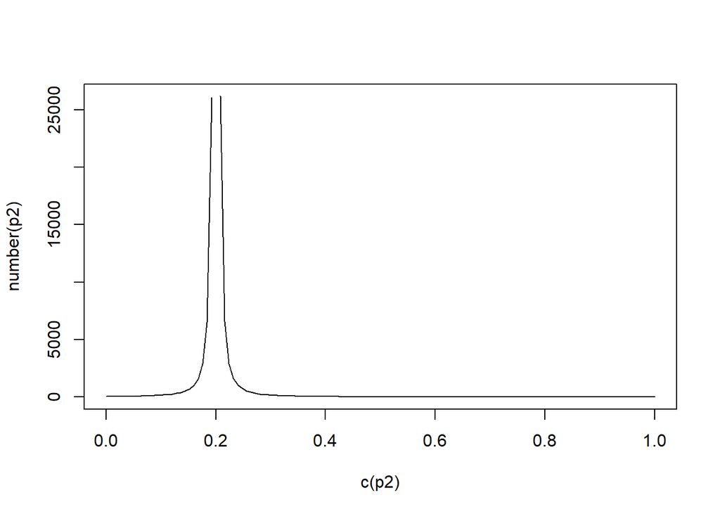

```r
ceiling_dec <- function(x, level=1) round(x + 5*10^(-level-1), level)

number=function(p2){
  ans1<-((-0.3264*(0.16+p2*(1-p2))**0.5 - 1.96*(0.32)**0.5) /(p2-0.2))**(2)
#  ans2<-((-0.3264*(0.16+p2*(1-p2))**0.5 + 1.96*(0.32)**0.5) /(p2-0.2))**(2)
#  ans = ceiling_dec(c(ans1,ans2),0)
  return (ans1)
}
p2=seq(0,1,0.008)
plot(c(p2),number(p2),type='l')
```

at $\alpha$=0.01

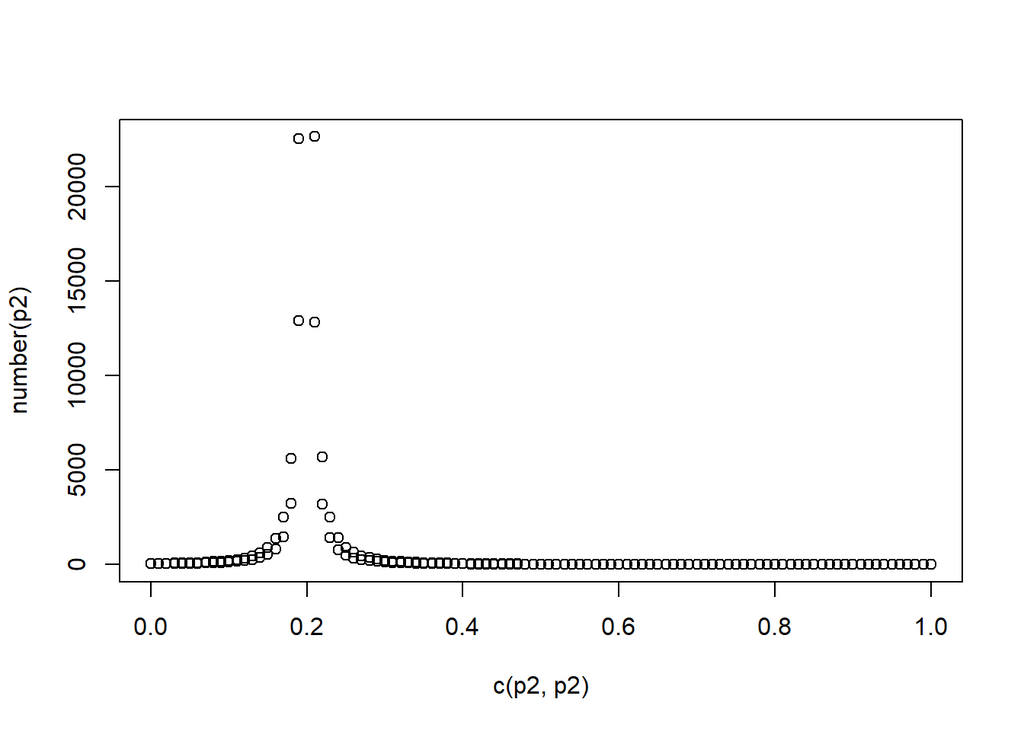

```r
number=function(p2){
  ans1<-((-0.3264*(0.16+p2*(1-p2))**0.5 - 2.33*(0.32)**0.5) /(p2-0.2))**(2)
  ans2<-((-0.3264*(0.16+p2*(1-p2))**0.5 + 2.33*(0.32)**0.5) /(p2-0.2))**(2)
  ans = ceiling_dec(c(ans1,ans2),0)
  return (ans)
}
p2=seq(0,1,0.01)
plot(c(p2,p2),number(p2))
```

# ———————————————————————————-

# Q3

## (a)

$H_{0}: p = 0.25$ vs $H_{1}: p \neq 0.25$

```r
Variable = c('ID number','Age','FEV','Height','Sex','Smoking status')
data=read.table("C:\\Users\\xx958\\OneDrive\\桌面\\nycu 碩一_上\\生物統計\\HW01\\FEV.TXT",col.names=Variable)
binom.test(sum(data['FEV']>3),length(data[[1]]),p=0.25,alt='two.sided')
```

```
##
##  Exact binomial test
##
## data:  sum(data["FEV"] > 3) and length(data[[1]])
## number of successes = 203, number of trials = 654, p-value = 0.0004967
## alternative hypothesis: true probability of success is not equal to 0.25
## 95 percent confidence interval:
##  0.2750987 0.3474182
## sample estimates:
## probability of success
##              0.3103976
```

```r
prop.test(sum(data['FEV']>3),length(data[[1]]),p=0.25,alt='two.sided')
```

```
##
##  1-sample proportions test with continuity correction
##
## data:  sum(data["FEV"] > 3) out of length(data[[1]]), null probability 0.25
## X-squared = 12.404, df = 1, p-value = 0.0004285
## alternative hypothesis: true p is not equal to 0.25
## 95 percent confidence interval:
##  0.2753966 0.3476605
## sample estimates:
##         p
## 0.3103976
```

# Conclusion : since p-value = 0.0004967 or 0.0004285 < 0.05 = $\alpha$ Thus reject $H_0$ (i.e the proportion of having perfect pulmonary function is not equal to 0.25 )

## (b)

$H_{0}: odds\ ratio = 1$ vs $H_{1}: odds\ ratio \neq 1$

```r
data['perfect_pulmonary'] = as.factor(data['FEV']>3)

table_Sex_and_perfect_pulmonary <- data%>%
  group_by(Sex,perfect_pulmonary)%>%
  summarise(n=n())
m = matrix(table_Sex_and_perfect_pulmonary$n,c(2,2),dimnames = list(c('Female','male'),c('no','yes')),byrow = T)
print(m)
```

```
##         no yes
## Female 240  78
## male   211 125
```

```r
R1=m[2,2]/(m[2,1]+m[2,2])
R0=m[1,2]/(m[1,1]+m[1,2])
odds1=R1/(1-R1)
odds0=R0/(1-R0)
OR = odds1/odds0
cat('odds ratio is ',OR)
```

```
## odds ratio is  1.822822
```

check

```r
fisher.test(m)$estimate
```

```
## odds ratio
##   1.821169
```

```r
chisq.test(m,correct = T)
```

```
##
##  Pearson's Chi-squared test with Yates' continuity correction
##
## data:  m
## X-squared = 11.675, df = 1, p-value = 0.0006333
```

```r
prop.test(m[1:2,2],rowSums(m))
```

```
##
##  2-sample test for equality of proportions with continuity correction
##
## data:  m[1:2, 2] out of rowSums(m)
## X-squared = 11.675, df = 1, p-value = 0.0006333
## alternative hypothesis: two.sided
## 95 percent confidence interval:
##  -0.19985286 -0.05362873
## sample estimates:
##    prop 1    prop 2
## 0.2452830 0.3720238
```

```r
prop.test(m[1:2,2],rowSums(m),alt='less')
```

```
##
##  2-sample test for equality of proportions with continuity correction
##
## data:  m[1:2, 2] out of rowSums(m)
## X-squared = 11.675, df = 1, p-value = 0.0003167
## alternative hypothesis: less
## 95 percent confidence interval:
##  -1.00000000 -0.06489118
## sample estimates:
##    prop 1    prop 2
## 0.2452830 0.3720238
```

# Conclusion : since p_value = 0.000633 < 0.05 = $\alpha$ , Thus reject $H_0$(i.e odds ratio $\neq$ 1) , furthermore male is superior than female at perfect_pulmonary

## (c)

```r
data['age_class']=1
data['age_class'][4<data['Age'] & data['Age']<10] = 1
data['age_class'][9<data['Age'] & data['Age']<15] = 2
data['age_class'][14<data['Age'] & data['Age']<20] = 3

table_age_class_and_perfect_pulmonary <- data%>%
  group_by(age_class,perfect_pulmonary)%>%
  summarise(n=n())
m = matrix(table_age_class_and_perfect_pulmonary$n,c(3,2),dimnames = list(c('5~9','10~14','15~20'),c('no','yes')),byrow = T)
print(m)
```

```
##        no yes
## 5~9   298  11
## 10~14 141 155
## 15~20  12  37
```

$H_{0}: P1 = P2 = P3$ vs $H_{1}: not H_0$  
the number of perfect_pulmonary in 5~9 is binomal distibution (309,P1) P1 代表 5~9 中 perfect_pulmonary 的比例  
the number of perfect_pulmonary in 10~14 is binomal distibution (296,P2) P2 代表 10~14 中 perfect_pulmonary 的比例  
the number of perfect_pulmonary in 15~20 is binomal distibution (49,P3) P3 代表 15~20 中 perfect_pulmonary 的比例

```r
chisq.test(m,correct = T)
```

```
##
##  Pearson's Chi-squared test
##
## data:  m
## X-squared = 217.17, df = 2, p-value < 2.2e-16
```

Conclusion : p_value << 0.05 = $\alpha$ , reject $H_0$ (i.e 比例不同)

$H_{0}: P1 = P2$ vs $H_{1}: P1 < P2$

```r
prop.test(m[1:2,2],rowSums(m)[1:2],correct = T,alt='less')
```

```
##
##  2-sample test for equality of proportions with continuity correction
##
## data:  m[1:2, 2] out of rowSums(m)[1:2]
## X-squared = 178.42, df = 1, p-value < 2.2e-16
## alternative hypothesis: less
## 95 percent confidence interval:
##  -1.0000000 -0.4339433
## sample estimates:
##     prop 1     prop 2
## 0.03559871 0.52364865
```

Conclusion : p_value << 0.05 = $\alpha$ , reject $H_0$(i.e 10~14 比 5~9 have a higher proportion of having perfect pulmonary function)

$H_{0}: P2 = P3$ vs $H_{1}: P2 < P3$

```r
prop.test(m[2:3,2],rowSums(m)[2:3],correct = T,alt='less')
```

```
##
##  2-sample test for equality of proportions with continuity correction
##
## data:  m[2:3, 2] out of rowSums(m)[2:3]
## X-squared = 8.2115, df = 1, p-value = 0.002081
## alternative hypothesis: less
## 95 percent confidence interval:
##  -1.0000000 -0.1077991
## sample estimates:
##    prop 1    prop 2
## 0.5236486 0.7551020
```

Conclusion : p_value=0.00208 < 0.05 = $\alpha$ , reject $H_0$(i.e 15~20 比 10~14 have a higher proportion of having perfect pulmonary function)

# ———————————————————————————

# Q4

## (a)

$P_i$ 代表各城市中 Number children with caries free teeth 的比例

```r
m=matrix(c(243,16,83,36,60,32,31,31,39,12),c(2,5),dimnames = list(c('Number_children_with_caries','Number_children_with_caries_free_teeth'),c('Essex','Slough','Harwick','Burnham','Meresa')))
```

$H_{0}: P1 = P2 = P3 = P4 = P5$ vs $H_{1}: not H_0$

```r
chisq.test(m)
```

```
##
##  Pearson's Chi-squared test
##
## data:  m
## X-squared = 80.216, df = 4, p-value < 2.2e-16
```

```r
prop.test(m[2,],colSums(m))
```

```
##
##  5-sample test for equality of proportions without continuity
##  correction
##
## data:  m[2, ] out of colSums(m)
## X-squared = 80.216, df = 4, p-value < 2.2e-16
## alternative hypothesis: two.sided
## sample estimates:
##     prop 1     prop 2     prop 3     prop 4     prop 5
## 0.06177606 0.30252101 0.34782609 0.50000000 0.23529412
```

# Conclusion : since p-value << 0.05 = $\alpha$ ,Thus reject $H_0$

## (b)

```r
prop.test(m[2,4:5],colSums(m[1:2,4:5]),alt='greater')
```

```
##
##  2-sample test for equality of proportions with continuity correction
##
## data:  m[2, 4:5] out of colSums(m[1:2, 4:5])
## X-squared = 7.2326, df = 1, p-value = 0.00358
## alternative hypothesis: greater
## 95 percent confidence interval:
##  0.1038173 1.0000000
## sample estimates:
##    prop 1    prop 2
## 0.5000000 0.2352941
```

Express P4>P5

```r
p = c(0.06177606 , 0.30252101 , 0.34782609 , 0.50000000 , 0.23529412 )
N = length(p)
value = critical.range = c()

## Compute critical values.
for (i in 1:(N-1))
   { for (j in (i+1):N)
    {
     value = c(value,(abs(p[i]-p[j])))
     critical.range = c(critical.range,
      sqrt(qchisq(.95,4))*sqrt(p[i]*(1-p[i])/300 + p[j]*(1-p[j])/300))
    }
   }

m=round(cbind(value,critical.range),3)
m[,1] > m[,2]
```

```
##  [1]  TRUE  TRUE  TRUE  TRUE FALSE  TRUE FALSE  TRUE FALSE  TRUE
```

Can see that  
(P1 , P2),(P1 , P3),(P1 , P4),(P1 , P5)  
(P2 , P4),(P3 , P4),(P4 , P5) there are different ,but not express proportions of children caries free teeth high with fluoride high